# C05 — Niepewność estymaty: przedział, bootstrap i test jednej próby

Zarządzanie informacją — ćwiczenie i zadanie Z05 — 2026/27

2026/27

# Początek pracy na ćwiczeniu C05

Otwórz swój projekt kursu w Posit Cloud albo RStudio na własnym komputerze; pakiet kursu `badaniaZI` jest w nim zainstalowany. Dwa polecenia z następnego bloku wpisujesz w konsoli RStudio, czyli w dolnym panelu ze znakiem `>`; w miejsce `TWOJE_ID` wpisz swoje ID, a w miejsce `Imię Nazwisko` — swoje imię i nazwisko. Dokument PDF zawiera dwa polecenia jako tekst instrukcji.

```r
library(badaniaZI)
rozpocznij_zajecia("C05", id_studenta = "TWOJE_ID", student = "Imię Nazwisko")
```

Sprawdź w komunikacie ID oraz imię i nazwisko. Przy pierwszym starcie funkcja tworzy folder `moje-badania` i zapisuje w nim oba dane; pliki pracy zachowują je także po zamknięciu projektu, a imię i nazwisko trafiają do nazwy oddawanego pliku.

Funkcja `rozpocznij_zajecia()` otwiera własny plik `zadanie.Rmd`, zapamiętuje katalog pracy i kopiuje do folderu `moje-badania/materialy` wersję HTML i PDF ćwiczenia oraz rubrykę zadania. Pracuj w otwartym pliku `zadanie.Rmd` do końca zajęć. Najpierw uruchom blok `przygotowanie`, a potem kolejne części LEARN i CHALLENGE. Przy problemie poproś prowadzącego o pomoc; plik pracy i własne ID pozostają bez zmian.

Pierwszy chunk, `przygotowanie`, wczytuje gotowy skrypt `analiza.R`. Skrypt tworzy zbiór S02 po trzech regułach ćwiczenia C02 (usunięcie identycznych duplikatów, kod 99 w pozycjach ankiety jako brak, czas spoza 0–120 minut jako brak) i liczy indeks sześciu pozycji według reguły 5/6 z ćwiczenia C04. Funkcja `analiza_jednej_sredniej()` wykonuje test t, bootstrap i losowe zmiany znaków ze stałym ziarnem losowania. Skrypt zawiera też dane portalu do części CHALLENGE, małe demonstracje oraz funkcje wyświetlające tabele i wykresy.

# Zespół pyta o więcej niż „średnia jest powyżej trzech”

Biblioteka widzi korzystną średnią ocenę katalogu i pyta, czy średnia wystarcza do decyzji. Analiza rozdziela trzy sprawy: o ile średnia przewyższa odniesienie, jak precyzyjnie oszacowano różnicę i jak nietypowy jest wynik w określonym modelu zerowym. Znaczenie dla usługi ocenia się po trzech krokach analizy.

Indeks S02 opisuje deklarowaną użyteczność katalogu według dydaktycznej reguły sześciu pozycji (ćwiczenie C04). Wartość 3 to środek skali 1–5, przyjęty umownie jako punkt odniesienia.

Pytanie główne brzmi: jaka jest średnia indeksu i jej różnica od 3? Wartość w próbie jest estymatą; estymanda populacyjna wymaga opisu populacji i warunków. Dane są syntetyczne, więc liczby opisują zbiór dydaktyczny.

## Przebieg spotkania

Przeznacz około 5 minut na odtworzenie pracy, 30 minut na pięć bloków LEARN, 50 minut na pięć zadań CHALLENGE i 5 minut na zapis oraz oddanie. W LEARN uruchamiasz gotowy kod i porównujesz wynik z podaną interpretacją. W CHALLENGE piszesz własne krótkie akapity pod wynikami, poza blokiem R. Gdy odczyt wyniku sprawia trudność, pytasz prowadzącego. Rozwinięcia po części obowiązkowej służą powtórce i pozostają poza oceną.

Portal w CHALLENGE ma gotowe indeksy; projekt indywidualny rozpoczyna się na ćwiczeniu C09 (Warsztat projektu). Uruchamiasz gotowe funkcje z `analiza.R`; Twoją pracą są odczyt, interpretacja i uzasadnienie.

Bloki LEARN kończą się **wzorcem zapisu** — przykładowym zdaniem według standardu APA (*Publication Manual of the American Psychological Association*, 7. wydanie, 2020): symbol statystyczny kursywą, stopnie swobody w nawiasie, przedział w nawiasie kwadratowym, przecinek jako separator dziesiętny. Na ćwiczeniu C05 wzorce dotyczą jednej średniej: opisu, testu t, efektu z przedziałem, bootstrapu i zmian znaków. Zadania CHALLENGE stosują wzorce do indeksu portalu.

# LEARN 1: cel, jednostka i kierunek

Elementy analizy jednej średniej

| Element analizy | Definicja w S02 |
| --- | --- |
| Jednostka | Osoba z ważnym indeksem |
| Zmienna | Indeks deklarowanej użyteczności katalogu, 1–5 |
| Parametr średniej | $\mu$ w określonym modelu populacji |
| Wartość odniesienia | $\mu_0=3$ punkty |
| Estymanda różnicy | $\Delta=\mu-3$ |
| Estymata | $\widehat\Delta=\bar{x}-3$ |
| Hipoteza zerowa | $H_0:\mu=3$, równoważnie $\Delta=0$ |
| Alternatywa dwustronna | $H_1:\mu\neq3$ |

Po ukierunkowaniu pozycji wyższy indeks oznacza korzystniejszą deklarację. Dodatnia różnica opisuje położenie średniej względem liczby 3 w jednym pomiarze; zmiana w czasie wymaga pomiaru przed i po, a efekt przyczynowy — projektu z interwencją.

Ocena znaku zależy od zmiennej i kolejności odejmowania: dodatni znak czasu oznacza dłuższe wykonanie niż odniesienie, a dodatni znak indeksu — korzystniejszą deklarację.

## Test dwustronny

Dwustronna alternatywa obejmuje średnią wyższą i niższą od odniesienia, a kierunek różnicy odczytuje się z estymaty. Rodzaj alternatywy ustala się przed obliczeniem wyniku. Zadanie Z05 stosuje test dwustronny, więc „bardziej skrajny” oznacza duże odchylenie w dowolnym kierunku.

## Najpierw osoby i rozkład

Reguła 5/6 daje brak indeksu u osoby z mniej niż pięcioma ważnymi pozycjami. N w teście to liczba ważnych indeksów: 147.

Tabela „Osoby, średnia, niepewność i efekt” podaje jedną wielkość w wierszu: N = 147 ważnych indeksów, 1 brak, średnia 3,292, SD 0,727, SE 0,060, odniesienie 3, różnica 0,292 i d = 0,402. SE i d korzystają z tego samego SD, a opisują inne wielkości.

```r
opis <- opis_sredniej(wynik)
print(opis)
```

**Osoby, średnia, niepewność i efekt**

| Miara | Wartość |
| --- | --- |
| N (ważne indeksy) | 147,000 |
| Braki indeksu | 1,000 |
| Średnia [pkt] | 3,292 |
| SD [pkt] | 0,727 |
| SE średniej [pkt] | 0,060 |
| Odniesienie [pkt] | 3,000 |
| Różnica od odniesienia [pkt] | 0,292 |
| d (bez jednostki) | 0,402 |

Wartości opisują syntetyczną próbę; ocena istotności przychodzi po opisie.

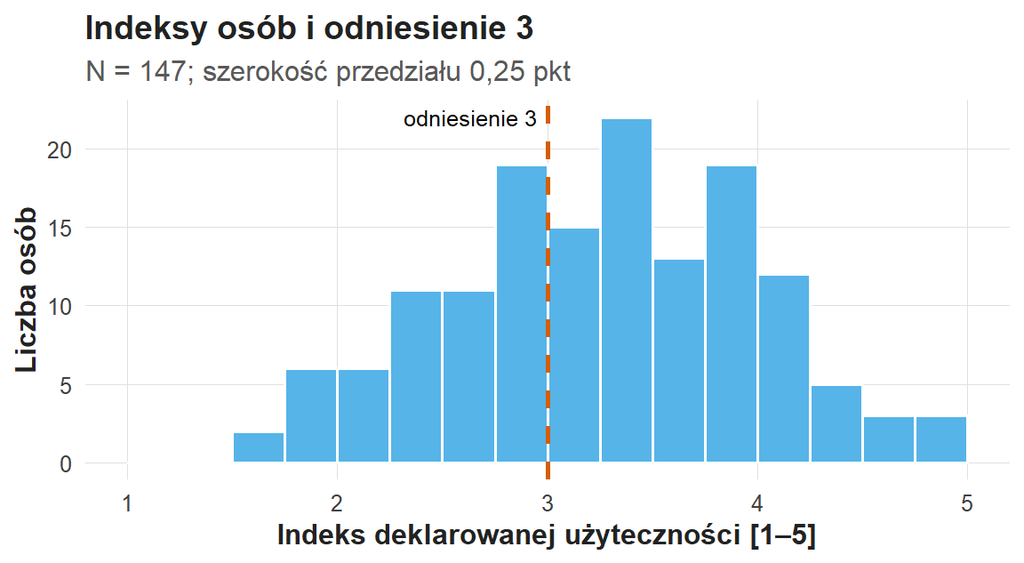

Indeksy osób i odniesienie 3: histogram 147 indeksów z przedziałami po 0,25 punktu. Oś pozioma: indeks 1–5; oś pionowa: liczba osób. Indeksy leżą od 1,6 do 5,0; najwyższy słupek, 22 osoby, stoi nad przedziałem od 3,25 do 3,5; linia przerywana oznacza odniesienie 3.

```r
osoby <- pokaz_wykres(wykres_danych)
print(osoby)
```

Na wykresie „Indeksy osób i odniesienie 3” słupek oznacza liczbę osób. Dalsze histogramy mają inne jednostki: średnią repliki bootstrapowej i statystykę po zmianie znaków.

Indeks jest w kursie przybliżoną zmienną ilościową; ograniczony zakres i pochodzenie z pozycji porządkowych należą do opisu pomiaru (wykład W02 i ćwiczenie C04).

**Wzorzec zapisu opisu średniej (APA).**

> Indeks deklarowanej użyteczności katalogu obliczono dla 147 osób (1 brak); średnia wyniosła *M* = 3,29 (*SD* = 0,73) na skali 1–5, a różnica od umownego odniesienia 3 — 0,29 punktu.

# LEARN 2: SE, t i stopnie swobody

$$SE=\frac{s}{\sqrt n},\qquad
t=\frac{\bar{x}-\mu_0}{SE},$$

gdzie $s$ to SD indeksów, a $n$ — liczba ważnych indeksów. SE opisuje zmienność średniej między hipotetycznymi niezależnymi próbami w standardowym modelu, a SD — rozrzut osób. SD osób wynosi 0,727, a SE średniej 0,060: osoby różnią się dwunastokrotnie bardziej niż średnie hipotetycznych prób 147 osób.

Licznik t to różnica 0,292 punktu, a mianownik — 0,060 punktu niepewności średniej. Statystyka wynosi 4,876 i jest liczbą bez jednostki: średnia leży 4,88 błędu standardowego powyżej odniesienia.

Tabela „Dwustronny test t jednej średniej” podaje t = 4,876, df = 146 i p < 0,0001. Funkcja formatująca zapisuje bardzo małe p jako „< 0,0001”.

```r
test <- test_sredniej(wynik)
print(test)
```

**Dwustronny test t jednej średniej**

| t | df | p |
| --- | --- | --- |
| 4,876 | 146 | < 0,0001 |

Stopnie swobody wynoszą $n-1=146$ i wskazują rozkład odniesienia t, z którego odczytuje się skrajność statystyki. Wykres „Rozkład t(146) i obserwowane t = 4,876” przedstawia rozkład t(146).

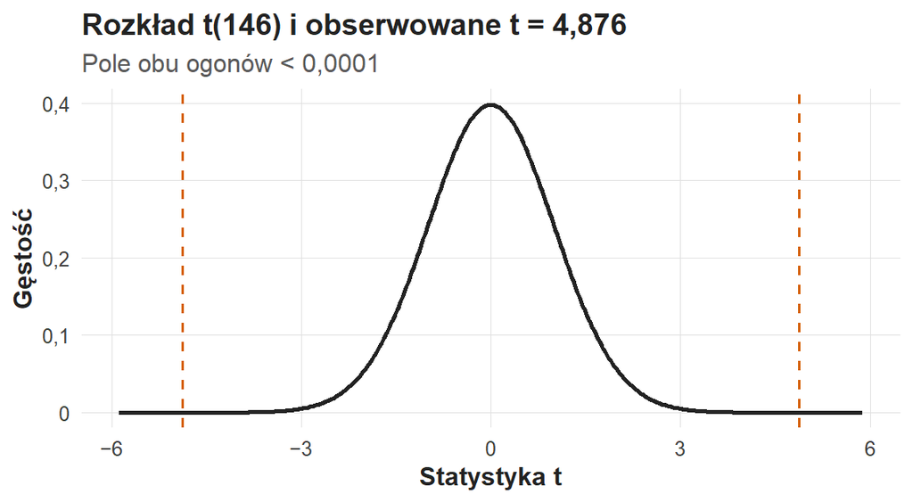

Rozkład t(146) i obserwowane t = 4,876. Oś pozioma: statystyka t; oś pionowa: gęstość. Krzywa jest symetryczna wokół 0, a 99,7% jej pola leży między −3 a 3. Linie przerywane przy −4,876 i 4,876 leżą daleko w ogonach; pole obu ogonów wynosi 0,0000028.

```r
rozklad_t <- pokaz_wykres(wykres_t)
print(rozklad_t)
```

Dla niezależnych obserwacji z populacji o rozkładzie normalnym test t ma dokładne uzasadnienie rozkładowe (wykład W03). Przy innych rozkładach test korzysta z przybliżenia, którego jakość zależy od kształtu rozkładu i $n$; niezależność obserwacji wynika z projektu.

## Polecenie R jako zdanie

Oryginalny wydruk testu podaje nazwę metody, alternatywę, przedział i estymatę. W wywołaniu `t.test(x, mu = 3)` napis „confidence interval” dotyczy średniej.

```r
wydruk_R <- oryginal_testu_sredniej(wynik)
print(wydruk_R)
```

```
    One Sample t-test

data:  wazne
t = 4.8756, df = 146, p-value = 2.8e-06
alternative hypothesis: true mean is not equal to 3
95 percent confidence interval:
 3.173809 3.410771
sample estimates:
mean of x
  3.29229
```

Argument `mu` wskazuje wartość hipotezy zerowej; dane i średnia pozostają te same. Zmiana odniesienia zmienia różnicę i wynik testu, a dwustronny przedział tej samej średniej pozostaje ten sam. Opis argumentów zawiera [dokumentacja R dla t.test](https://stat.ethz.ch/R-manual/R-devel/library/stats/html/t.test.html).

## Wartość p i model zerowy

Klasyczne p wynosi $2{,}8\cdot10^{-6}$, czyli 0,0000028: tak rzadko pojawia się statystyka co najmniej tak skrajna przy $H_0$ i założeniach testu. Zapis `2.8e-06` oznacza bardzo małą liczbę dodatnią. Raport podaje p < 0,001 razem z estymatą i przedziałem.

**Wzorzec zapisu testu t (APA).**

> Średni indeks był wyższy od umownego odniesienia 3, *t*(146) = 4,88, *p* < 0,001 (test dwustronny).

# LEARN 3: efekt i dwa przedziały

Klasyczny przedział średniej ma postać:

$$CI_{95\%}(\mu)=
\left[\bar{x}-t_{0{,}975;\,n-1}SE,\;
\bar{x}+t_{0{,}975;\,n-1}SE\right],$$

gdzie $t_{0{,}975;\,146}=1{,}976$. Przedział różnicy $\Delta=\mu-3$ powstaje przez odjęcie 3 od obu końców; szerokość pozostaje ta sama, a zmienia się parametr i jego wartość zerowa.

Tabele „95% CI średniej [pkt]” i „95% CI różnicy od odniesienia [pkt]” podają wyniki metody t: średnia — od 3,174 do 3,411, różnica — od 0,174 do 0,411.

```r
przedzialy_t <- przedzialy_sredniej(wynik, metoda = "t")
print(przedzialy_t)
```

**95% CI średniej [pkt]**

| Metoda | Estymata | Dolna granica | Górna granica |
| --- | --- | --- | --- |
| t | 3,292 | 3,174 | 3,411 |

**95% CI różnicy od odniesienia [pkt]**

| Metoda | Estymata | Dolna granica | Górna granica |
| --- | --- | --- | --- |
| t | 0,292 | 0,174 | 0,411 |

Zdanie „różnica 0,292, CI [3,174; 3,411]” łączy estymatę różnicy z przedziałem średniej; poprawny zapis brzmi „różnica 0,292, CI [0,174; 0,411]”.

Przedział średniej leży w całości powyżej 3, a przedział różnicy — powyżej 0. Dla pary „dwustronny test t na poziomie 0,05 i przedział t 95%” obowiązuje zgodność:

$$\mu_0\notin CI_{95\%}(\mu)\iff p<0{,}05 .$$

Zgodność dotyczy pary: dwustronny test t i przedział t (wykład W03).

## Co oznacza 95%

Poziom ufności jest własnością procedury powtarzanej przy jej założeniach: w wielu powtórzeniach badania 95% tak zbudowanych przedziałów obejmuje $\mu$. Indeksy osób leżą od 1,6 do 5,0 — znacznie szerzej niż przedział średniej od 3,174 do 3,411. Wartości blisko granic przedziału są zgodne z danymi w podobnym stopniu jak wartości tuż za granicą.

## Efekt surowy i efekt standaryzowany

Standaryzowany efekt d i jego związek z t mają postać:

$$d=\frac{\bar{x}-\mu_0}{s},\qquad t=d\sqrt n=0{,}402\cdot\sqrt{147}=4{,}876 .$$

Efekt d = 0,402 dzieli różnicę przez SD osób, a t dzieli ją przez SE, więc t rośnie z $\sqrt n$ przy stałym d. Efekt surowy ma jednostkę punktów indeksu, a d jest liczbą bez jednostki.

Pierwsza informacja dla zespołu brzmi: „0,292 punktu powyżej umownego odniesienia”. Znaczenie różnicy 0,292 punktu ocenia się względem celu usługi i jakości pomiaru.

**Wzorzec zapisu efektu i przedziału (APA).**

> Średni indeks wyniósł *M* = 3,29 punktu, 95% CI [3,17; 3,41]; różnica od odniesienia 3 wyniosła 0,29 punktu, 95% CI [0,17; 0,41], *d* = 0,40.

# LEARN 4: bootstrap i zmiana znaków mają różne cele

Bootstrap traktuje próbę jako empiryczne przybliżenie rozkładu. Losuje $n$ obserwacji ze zwracaniem i liczy średnią; średnia jest jedną repliką estymaty.

W małej demonstracji sześć indeksów wynosi 2, 3, 3, 4, 4 i 5, a ich średnia — 3,5. Tabela „Jedno losowanie sześciu osób ze zwracaniem” podaje replikę z osobami numer 2, 2, 6, 1, 4 i 4. Losowanie zmienia liczbę wystąpień osoby w replice.

```r
replika <- jedna_replika_do_odczytu()
print(replika)
```

**Jedno losowanie sześciu osób ze zwracaniem**

| Miejsce w próbie | Wylosowana osoba | Indeks |
| --- | --- | --- |
| 1 | 2 | 3 |
| 2 | 2 | 3 |
| 3 | 6 | 5 |
| 4 | 1 | 2 |
| 5 | 4 | 4 |
| 6 | 4 | 4 |

Replika zawiera wartości 3, 3, 5, 2, 4 i 4, więc jej średnia także wynosi 3,5; inne losowania dają inne średnie. Powtórzenie osoby wynika z definicji losowania ze zwracaniem. Losowanie ze zwracaniem zmienia skład próby, a więc średnią; przestawienie kolejności tych samych sześciu wartości pozostawia średnią bez zmian.

## Wiele replik i przedział bootstrapowy

Dla S02 funkcja tworzy $B=1999$ replik po 147 losowań. Percentylowy przedział bootstrapowy i bootstrapowe SE mają postać:

$$CI^{\text{boot}}_{95\%}=\left[\bar x^*_{(0{,}025)},\ \bar x^*_{(0{,}975)}\right],\qquad
SE_{\text{boot}}=\sqrt{\frac{1}{B-1}\sum_{b=1}^{B}\left(\bar x^*_b-\overline{\bar x^*}\right)^2},$$

gdzie $\bar x^*_b$ to średnia repliki $b$, a $\bar x^*_{(q)}$ — kwantyl rzędu $q$ średnich replik. W S02 $SE_{\text{boot}}=0{,}0605$ wobec klasycznego $SE=0{,}060$.

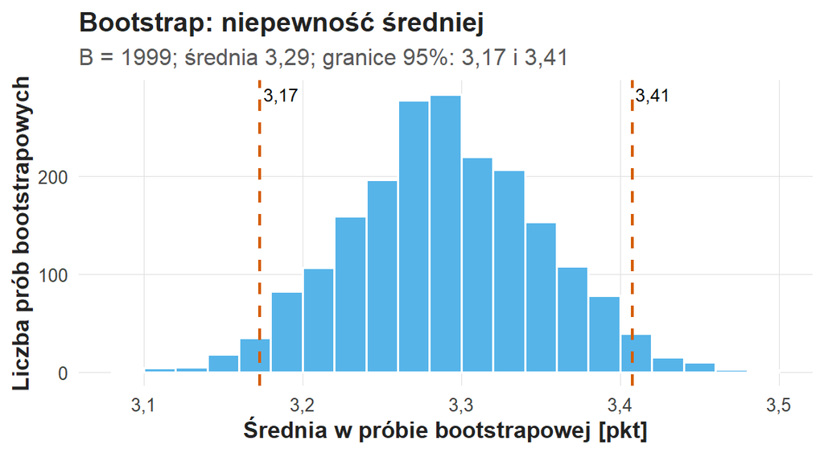

Bootstrap: niepewność średniej. Histogram 1999 średnich prób bootstrapowych z przedziałami po 0,02 punktu. Oś pozioma: średnia w próbie bootstrapowej; oś pionowa: liczba prób. Średnie leżą od 3,10 do 3,48 wokół średniej próby 3,29; linie przerywane przy 3,17 i 3,41 wyznaczają percentylowy przedział 95%.

```r
srednie_replik <- pokaz_wykres(wykres_bootstrap)
print(srednie_replik)
```

Bootstrap skupia się wokół średniej próby (3,29), bo odtwarza zmienność estymatora; hipotezę zerową wprowadza procedura zmian znaków.

Tabele przedziałów bootstrapowych podają: średnia — od 3,173 do 3,407, różnica — od 0,173 do 0,407. Przedziały bootstrapowe są bliskie klasycznym; zgodność dotyczy próby S02 i dwóch użytych metod.

```r
przedzialy_boot <- przedzialy_sredniej(wynik, metoda = "bootstrap")
print(przedzialy_boot)
```

**95% CI średniej [pkt]**

| Metoda | Estymata | Dolna granica | Górna granica |
| --- | --- | --- | --- |
| Bootstrap percentylowy | 3,292 | 3,173 | 3,407 |

**95% CI różnicy od odniesienia [pkt]**

| Metoda | Estymata | Dolna granica | Górna granica |
| --- | --- | --- | --- |
| Bootstrap percentylowy | 0,292 | 0,173 | 0,407 |

Bootstrap korzysta z wartości obecnych w próbie, więc mała próba odtwarza wyłącznie obserwowaną część rozkładu; dla danych zależnych losuje się jednostki wyższego poziomu, np. osoby ze wszystkimi ich zapytaniami. Liczba replik wpływa na dokładność obliczenia, a ograniczenia próby pozostają.

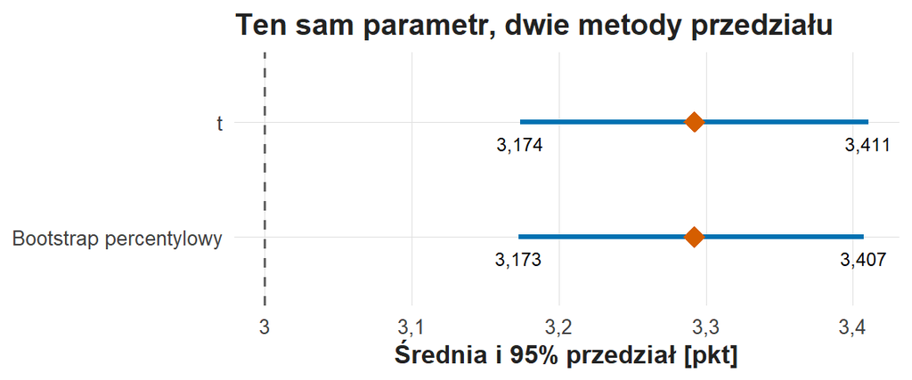

Ten sam parametr, dwie metody przedziału. Oś pozioma: średnia indeksu w punktach. Przedział t: od 3,174 do 3,411; bootstrap percentylowy: od 3,173 do 3,407; romby przy 3,292 oznaczają wspólną estymatę; linia przerywana przy 3 leży na lewo od obu odcinków.

```r
porownanie_ci <- pokaz_wykres(wykres_ci)
print(porownanie_ci)
```

Oba przedziały dotyczą średniej, mają wspólną estymatę i różnią się regułą wyznaczania granic. Metodę ocenia się po założeniach i własnościach, a wybiera przed obejrzeniem granic.

## Co zmienia procedura znaków

Test zerowy korzysta z odchyleń $e_i=x_i-\mu_0$. Przy $H_0$ i założeniu symetrii odchyleń znak każdego niezależnego odchylenia można zmienić, zachowując jego wielkość. Procedura mnoży odchylenia osób od odniesienia przez losowe znaki $\varepsilon_{ib}\in\{-1,+1\}$ i w każdym powtórzeniu liczy średnią.

Test zmian znaków zakłada symetrię odchyleń przy $H_0$: rozkład z wieloma małymi ujemnymi i kilkoma dużymi dodatnimi odchyleniami ma średnią 0 i łamie symetrię (rozwinięcie „Średnia i symetria: dwa warunki”). Warunki dopuszczalnych przestawień omawiają [Winkler i współautorzy (2014)](https://pmc.ncbi.nlm.nih.gov/articles/PMC4010955/).

## Wzór statystyki i skrajności

$$T_{\mathrm{obs}}=\frac{1}{n}\sum_i e_i,\qquad
T_b^*=\frac{1}{n}\sum_i \varepsilon_{ib}\,e_i,\qquad
p_{\mathrm{MC}}=\frac{1+\#\{b:\ |T_b^*|\geq|T_{\mathrm{obs}}|\}}{B+1}.$$

Statystyka obserwowana i statystyka po zmianie znaków mają tę samą definicję: średnia odchyleń w punktach. Klasyczne t jest liczbą bez jednostki, więc porównuje się p obu procedur.

Tabela „Zmiana znaków: T w punktach, p Monte Carlo” podaje $T_{\mathrm{obs}}=0{,}292$, 0 powtórzeń z $|T_b^*|\ge|T_{\mathrm{obs}}|$, $B=1999$ i $p_{\mathrm{MC}}=0{,}0005$.

```r
znaki <- test_znakow_sredniej(wynik)
print(znaki)
```

**Zmiana znaków: T w punktach, p Monte Carlo**

| T obserwowane [pkt] | Repliki co najmniej tak skrajne (k) | B | p_MC |
| --- | --- | --- | --- |
| 0,292 | 0 | 1999 | 0,0005 |

Wynik $(1+0)/(1999+1)=0{,}0005$ jest najmniejszą wartością osiągalną przy $B=1999$. Uzasadnienie dodania jedynki do licznika i mianownika podają [Phipson i Smyth (2010)](https://pubmed.ncbi.nlm.nih.gov/21044043/).

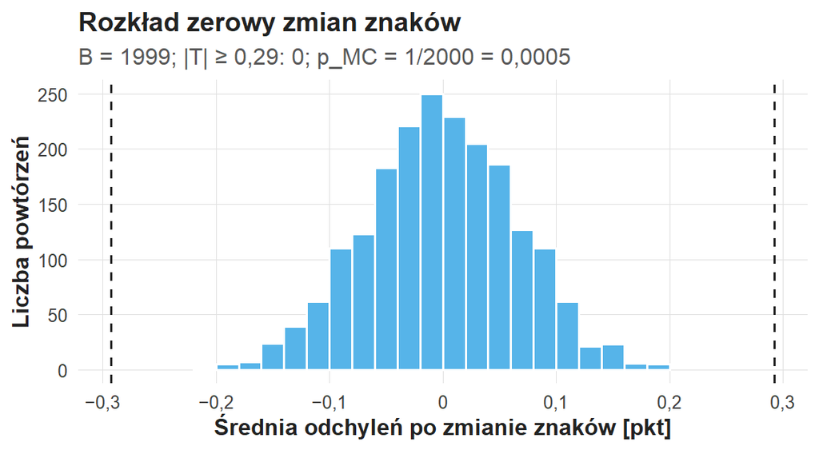

Rozkład zerowy zmian znaków: histogram 1999 średnich odchyleń po losowej zmianie znaków, z przedziałami po 0,02 punktu. Oś pozioma: średnia odchyleń od 3 w punktach; oś pionowa: liczba powtórzeń. Histogram jest symetryczny wokół zera i leży od −0,21 do 0,19; linie przerywane przy −0,292 i 0,292 leżą poza wszystkimi powtórzeniami, więc p Monte Carlo = 1/2000 = 0,0005.

```r
skrajnosc <- pokaz_wykres(wykres_zerowy)
print(skrajnosc)
```

Rozkład zerowy ma środek przy zerze z konstrukcji: losowe znaki równoważą odchylenia. Rozciąga się od −0,21 do 0,19, a $T_{\mathrm{obs}}=0{,}292$ leży poza nim.

Klasyczne p = 0,0000028 i $p_{\mathrm{MC}}=0{,}0005$ różnią się, bo $p_{\mathrm{MC}}$ ma rozdzielczość 1/2000 i dodatkowe założenie symetrii. Efekt w punktach jest w obu procedurach ten sam.

## Wynik przy umownym progu

W innym zbiorze wynik klasyczny i wynik Monte Carlo mogą leżeć po dwóch stronach 0,05 albo dokładnie na granicy. Przy wynikach po dwóch stronach 0,05 raport porównuje estymatę, przedział, założenia i dokładność losowania; mała zmiana p opisuje tę samą różnicę w danych.

Warunek „p < 0,05” wymaga wartości mniejszej od 0,05. Ziarno i nierówność ustala się przed analizą, a raport podaje uzyskaną wartość p z opisem jej położenia przy progu. Przy $B=1999$ udział skrajnych powtórzeń bliski 0,05 ma SE około 0,0049, co określa dokładność czwartego miejsca po przecinku.

## Trzy rozkłady do nazwania

Trzy rozkłady i ich jednostki

| Obraz | Jeden element oznacza | Pytanie |
| --- | --- | --- |
| Histogram danych | Indeks osoby | Jak zróżnicowani są respondenci? |
| Histogram bootstrapu | Średnią repliki ze zwracaniem | Jak zmienia się estymata? |
| Histogram zerowy | Statystykę po zmianie znaków | Jak skrajny jest wynik przy modelu zerowym? |

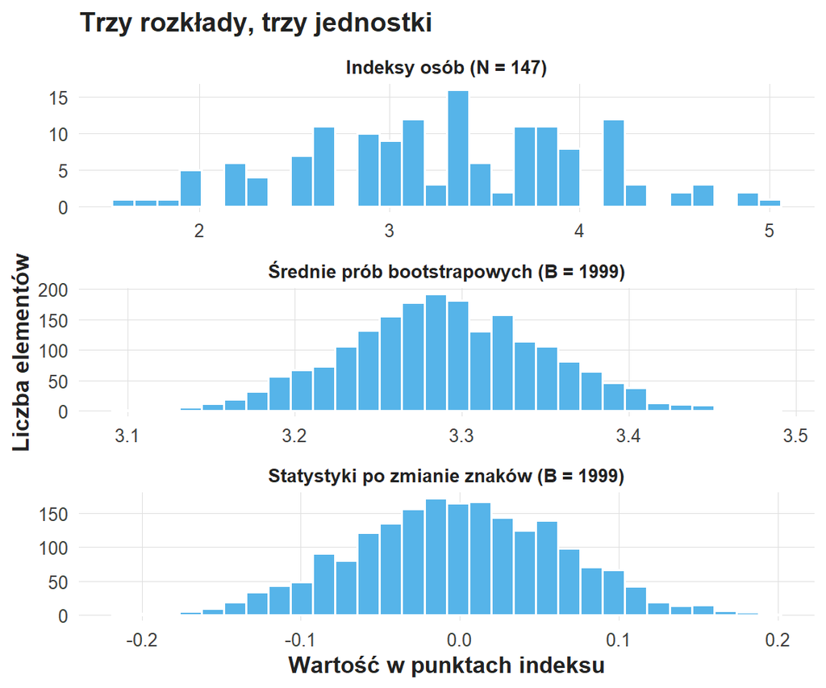

```r
trzy <- pokaz_wykres(wykres_trzy)
print(trzy)
```

Każdy histogram ma własną oś. Szerokość histogramu osób wiąże się z SD, szerokość histogramu średnich bootstrapowych — z niepewnością estymacji, a położenie obserwowanej statystyki na tle rozkładu zerowego służy obliczeniu p.

**Samokontrola:** osoba przedstawia histogram 1999 wartości i mówi, że przebadano 1999 użytkowników. Odczyt zaczyna się od pytania, czy wartości są indeksami osób, średnimi replik czy statystykami zerowymi. Liczbę osób podaje N danych, a liczbę replik B.

Druga osoba mówi: „bootstrap ma średnią 3,29, więc hipoteza zerowa ma średnią 3,29”. Zwykły bootstrap odtwarza informację z próby, a test zerowy buduje rozkład odniesienia przy $H_0$; nazwanie rozkładu jest pierwszym krokiem odczytu.

**Wzorzec zapisu bootstrapu i zmian znaków (APA).**

> Percentylowy przedział bootstrapowy (*B* = 1999) dla różnicy od 3 wyniósł [0,17; 0,41]. Test zmian znaków (*B* = 1999) dał *p*<sub>MC</sub> = 0,0005, ponieważ 0 z 1999 powtórzeń było co najmniej tak skrajnych jak obserwowana różnica; test zakłada symetrię odchyleń przy *H*<sub>0</sub>.

# LEARN 5: od wyniku do pełnego opisu

Blok `podsumowanie-wyniku` zestawia efekt, wynik klasyczny, wynik zmian znaków i przedziały. Każda tabela zachowuje nazwę parametru i metody; liczby wzorców zapisu pochodzą z tabel bloku `podsumowanie-wyniku`.

```r
raport <- podsumowanie_sredniej(wynik)
print(raport)
```

**Efekt i N**

| N | Różnica od 3 [pkt] | d |
| --- | --- | --- |
| 147 | 0,292 | 0,402 |

**Wynik klasyczny**

| t | df | p |
| --- | --- | --- |
| 4,876 | 146 | < 0,0001 |

**Wynik zmian znaków**

| T obserwowane [pkt] | Repliki co najmniej tak skrajne (k) | B | p_MC |
| --- | --- | --- | --- |
| 0,292 | 0 | 1999 | 0,0005 |

**95% CI średniej [pkt]**

| Metoda | Estymata | Dolna granica | Górna granica |
| --- | --- | --- | --- |
| t | 3,292 | 3,174 | 3,411 |
| Bootstrap percentylowy | 3,292 | 3,173 | 3,407 |

**95% CI różnicy od odniesienia [pkt]**

| Metoda | Estymata | Dolna granica | Górna granica |
| --- | --- | --- | --- |
| t | 0,292 | 0,174 | 0,411 |
| Bootstrap percentylowy | 0,292 | 0,173 | 0,407 |

## Wzorce zapisu dla S02

**Wzorzec zapisu warstwy liczbowej (APA).**

> Dla 147 ważnych indeksów średnia wyniosła *M* = 3,29 (*SD* = 0,73). Różnica od umownego odniesienia 3 wyniosła 0,29 punktu, 95% CI [0,17; 0,41], *t*(146) = 4,88, *p* < 0,001, *d* = 0,40.

**Wzorzec zapisu warstwy losowania (APA).**

> Percentylowy bootstrap (*B* = 1999) dał dla różnicy 95% CI [0,17; 0,41]. W 1999 losowych zmianach znaków średnia odchyleń co najmniej tak skrajna jak obserwowana wystąpiła 0 razy, stąd *p*<sub>MC</sub> = 0,0005; test zmian znaków zakłada symetrię odchyleń przy *H*<sub>0</sub>.

Warstwa badawcza: wynik oznacza przesunięcie średniej w stronę korzystnej deklaracji względem środka skali. Wynik dotyczy deklarowanej użyteczności w danych syntetycznych, a punkt odniesienia jest umowny.

Dwa krótkie akapity z nazwanymi przedziałami są czytelniejsze od jednego długiego zdania i zawierają parametr przedziału, znak różnicy oraz warunek procedury.

## Zero i próg praktyczny: dwie granice

Na potrzeby dyskusji zespół uznaje różnicę 0,20 punktu za wartą dalszej uwagi. Próg 0,20 jest hipotetyczną preferencją decydenta. Przedział [0,174; 0,411] wyklucza zero i obejmuje wartości po obu stronach 0,20; oszacowanie 0,292 leży powyżej progu.

Zdanie „wykluczono zerową różnicę” i zdanie „wykazano przekroczenie progu 0,20” dotyczą dwóch granic. Pierwsze wynika z dolnej granicy 0,174 > 0; drugie wymagałoby dolnej granicy powyżej 0,20.

Odczyt wyniku dla decydenta

| Pytanie decydenta | Odczyt w S02 |
| --- | --- |
| Oszacowanie punktowe | 0,292 punktu |
| Położenie CI względem zera | Oba końce dodatnie: 0,174 i 0,411 |
| Dolna granica CI względem progu 0,20 | 0,174, poniżej progu |
| Przyczyna efektu | Wymaga projektu z interwencją |

Odpowiedź statystyczna pasuje do decyzji: rekomendacja dotyczy dalszego sprawdzenia elementów usługi. Raport oddziela opis danych, interpretację modelową i rekomendację.

# CHALLENGE — samodzielna interpretacja oceny portalu

Portal studencki oceniono sześcioma pozycjami o deklarowanej przejrzystości procedur. Po ukierunkowaniu pozycji i regule 5/6 powstały indeksy 1–5; jedna z 25 osób ma brak indeksu. Portal jest osobną syntetyczną demonstracją. Przed analizą ustalono pytanie o różnicę średniej od odniesienia 3 i test dwustronny, a opiekun portalu wskazał 3,5 jako hipotetyczny cel użytkowy; obie wartości są umowne.

Każde z pięciu zadań ma ten sam układ:

1. **Zadanie** — jedno zdanie z przedmiotem opisu.
2. **Blok R** — uruchom go; wynik zawiera wszystkie liczby potrzebne do odpowiedzi.
3. **Wskazówki** — gdzie w wyniku szukać informacji, jak ją nazwać i wzór zdania do uzupełnienia.
4. **W akapicie wymagane** — elementy, które sprawdza prowadzący.
5. **Twój akapit** — pole odpowiedzi w ramce: znacznik w nawiasie kwadratowym zastępujesz własnym tekstem, a linie komentarza nad nim i pod nim pozostawiasz bez zmian.

Akapit liczy 3–5 zdań zwykłego tekstu, bez kodu R. Liczby przepisujesz z wyniku bloku, z jednostką, symbolem i mianownikiem.

## CHALLENGE 1: Estymanda i estymata

**Zadanie:** nazwij estymandę portalu i opisz średnią indeksu z SD, SE i różnicą od 3.

```r
opis_portalu <- opis_sredniej(portal_wynik)
print(opis_portalu)
```

**Osoby, średnia, niepewność i efekt**

| Miara | Wartość |
| --- | --- |
| N (ważne indeksy) | 24,000 |
| Braki indeksu | 1,000 |
| Średnia [pkt] | 3,312 |
| SD [pkt] | 0,704 |
| SE średniej [pkt] | 0,144 |
| Odniesienie [pkt] | 3,000 |
| Różnica od odniesienia [pkt] | 0,312 |
| d (bez jednostki) | 0,444 |

Blok wyświetla tabelę „Osoby, średnia, niepewność i efekt” z N ważnych indeksów, brakami, średnią, SD, SE, odniesieniem, różnicą od odniesienia i d.

*Wskazówki:*

- Estymanda to różnica średniego indeksu w populacji użytkowników portalu od 3; średnia próby jest jej estymatą.
- N osób to ważne indeksy plus braki; N analizy to liczba ważnych indeksów.
- SE = SD / $\sqrt{n}$: SD opisuje rozrzut osób, a SE — niepewność średniej.
- Efekt w punktach to różnica od odniesienia; d dzieli tę różnicę przez SD i jest liczbą bez jednostki.
- Wzorzec APA: „Indeks przejrzystości procedur obliczono dla [n] z [N] osób ([..] brak); średnia wyniosła *M* = [..] (*SD* = [..], *SE* = [..]) na skali 1–5, a różnica od umownego odniesienia 3 — [..] punktu (*d* = [..])”.

*W akapicie wymagane:* (i) estymanda słowami; (ii) N osób i N ważnych indeksów; (iii) średnia, SD i SE; (iv) słowny opis wzoru SE; (v) różnica od 3 jako efekt w punktach.

**Twój akapit S01.** Znacznik w nawiasie kwadratowym zastąp własnym tekstem.

## CHALLENGE 2: Przedziały i ich parametry

**Zadanie:** opisz oba 95% przedziały średniej i przedział różnicy oraz popraw zdanie o „95% studentów”.

```r
przedzialy_portalu <- przedzialy_portalu_do_raportu()
print(przedzialy_portalu)
```

**95% CI średniej [pkt]**

| Metoda | Estymata | Dolna granica | Górna granica |
| --- | --- | --- | --- |
| t | 3,312 | 3,015 | 3,610 |
| Bootstrap percentylowy | 3,312 | 3,021 | 3,583 |

**95% CI różnicy od odniesienia [pkt]**

| Metoda | Estymata | Dolna granica | Górna granica |
| --- | --- | --- | --- |
| t | 0,312 | 0,015 | 0,610 |
| Bootstrap percentylowy | 0,312 | 0,021 | 0,583 |

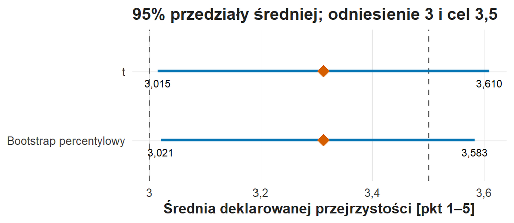

95% przedziały średniej indeksu portalu według dwóch metod. Oś pozioma: średnia w punktach skali 1–5; romb oznacza estymatę, a liczby przy końcach odcinków — granice przedziału; linie przerywane oznaczają odniesienie 3 i cel 3,5.

Blok wyświetla tabele „95% CI średniej [pkt]” i „95% CI różnicy od odniesienia [pkt]” (metoda t i bootstrap percentylowy) oraz wykres przedziałów średniej z liniami odniesienia 3 i celu 3,5.

*Wskazówki:*

- Przedział dotyczy parametru — średniej albo różnicy — a indeksy pojedynczych osób rozciągają się znacznie szerzej.
- Zdanie „95% studentów ma wynik w tym przedziale” myli przedział średniej z zakresem wyników osób; poprawny zapis mówi o niepewności oszacowania średniej.
- Przedział różnicy powstaje przez odjęcie 3 od obu granic przedziału średniej.
- Precyzję opisuje szerokość przedziału: różnica granic.
- Wzorzec APA: „Średni indeks wyniósł *M* = [..], 95% CI [[..]; [..]] (metoda *t*), a percentylowy przedział bootstrapowy [[..]; [..]]. Różnica od 3 wyniosła [..] punktu, 95% CI [[..]; [..]]”.

*W akapicie wymagane:* (i) oba 95% CI średniej z nazwą metody; (ii) klasyczny CI różnicy od 3; (iii) poprawione zdanie o 95%; (iv) opis precyzji na podstawie szerokości przedziału.

**Twój akapit S02.** Znacznik w nawiasie kwadratowym zastąp własnym tekstem.

## CHALLENGE 3: Dwa testy i ich założenia

**Zadanie:** opisz wynik testu t i testu zmian znaków wobec 3 oraz położenie obu wartości p względem 0,05.

```r
testy_portalu <- dwa_testy_sredniej(portal_wynik)
print(testy_portalu)
```

**Dwustronny test t**

| t | df | p |
| --- | --- | --- |
| 2,174 | 23 | 0,0403 |

**Losowe zmiany znaków**

| T obserwowane [pkt] | Repliki co najmniej tak skrajne (k) | B | p_MC |
| --- | --- | --- | --- |
| 0,312 | 99 | 1999 | 0,0500 |

Blok wyświetla tabelę „Dwustronny test t” (t, df, p) i tabelę „Losowe zmiany znaków” (obserwowane T, liczba replik co najmniej tak skrajnych k, B i $p_{\mathrm{MC}}$).

*Wskazówki:*

- Hipoteza zerowa: średnia w populacji wynosi 3; test dwustronny traktuje jako skrajne duże odchylenia w obu kierunkach.
- $p_{\mathrm{MC}}=(k+1)/(B+1)$: podstaw k i B z tabeli.
- Wartość p opisuje skrajność wyniku przy prawdziwej $H_0$ i założeniach testu; test zmian znaków wymaga symetrii odchyleń od 3 przy $H_0$.
- Warunek „p < 0,05” wymaga wartości mniejszej od 0,05; wartość równa 0,05 leży na granicy.
- Wzorzec APA: „Średni indeks różnił się od umownego odniesienia 3, *t*([df]) = [..], *p* = [..] (test dwustronny). Test zmian znaków (*B* = [..]) dał *p*<sub>MC</sub> = ([k] + 1)/([B] + 1) = [..]”.

*W akapicie wymagane:* (i) $H_0$ słowami i symbolem; (ii) t, df i p; (iii) T, k, B i $p_{\mathrm{MC}}$ z rachunkiem; (iv) znaczenie p i warunek symetrii; (v) położenie obu p względem 0,05.

**Twój akapit S03.** Znacznik w nawiasie kwadratowym zastąp własnym tekstem.

## CHALLENGE 4: Średnie replik i świat zerowy

**Zadanie:** nazwij jedną wartość każdego z dwóch rozkładów replik i odróżnij rozkład przedziału od rozkładu oceny skrajności.

```r
rozklady_portalu <- rozklady_portalu_do_odczytu()
print(rozklady_portalu)
```

**Dwa rozkłady replik portalu**

| Rozkład | Jedna wartość | Osoby N | B | Środek [pkt] | Odczyt |
| --- | --- | --- | --- | --- | --- |
| Bootstrap | średnia indeksów wylosowanych ze zwracaniem | 24 | 1999 | 3,311 | granice 95%: 3,021 i 3,583 |
| Zmiana znaków | średnia odchyleń od 3 po losowej zmianie znaków | 24 | 1999 | 0,002 | k = 99, p_MC = 0,0500 |

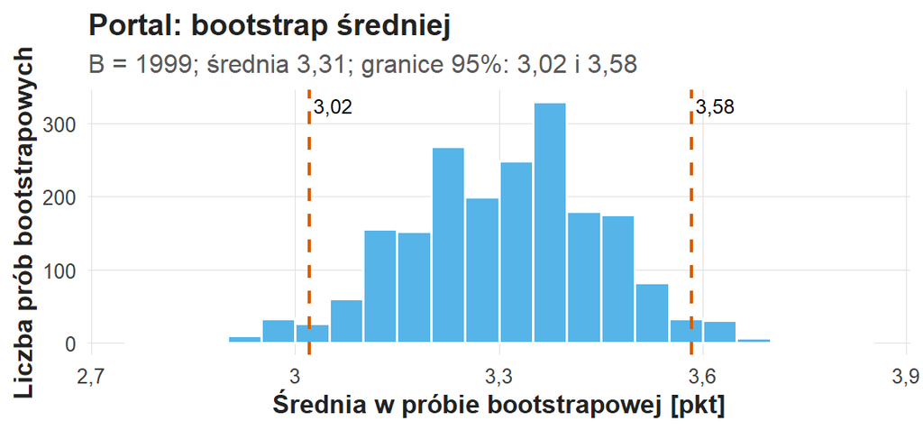

Portal: bootstrap średniej. Oś pozioma: średnia w próbie bootstrapowej w punktach; oś pionowa: liczba prób; linie przerywane wyznaczają percentylowy przedział 95%, a podtytuł podaje B, średnią replik i granice.

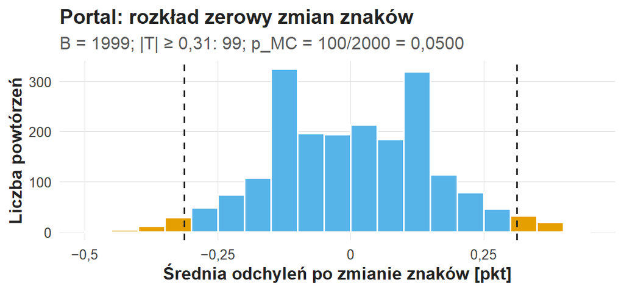

Portal: rozkład zerowy zmian znaków. Oś pozioma: średnia odchyleń od 3 po zmianie znaków; oś pionowa: liczba powtórzeń; linie przerywane oznaczają obserwowaną różnicę i jej odbicie, wyróżnione słupki zawierają powtórzenia na liniach lub dalej, a podtytuł podaje ich liczbę i p Monte Carlo.

Blok wyświetla tabelę „Dwa rozkłady replik portalu” (jedna wartość, liczba osób N, liczba replik B, środek rozkładu i odczyt) oraz dwa histogramy: bootstrap średniej i rozkład zerowy zmian znaków.

*Wskazówki:*

- N to liczba osób z ważnym indeksem; B to liczba powtórzeń obliczenia.
- Bootstrap skupia się wokół średniej próby, bo odtwarza zmienność estymatora; służy przedziałowi.
- Rozkład zerowy skupia się wokół zera, bo losowe znaki równoważą odchylenia przy $H_0$; służy ocenie skrajności obserwowanej różnicy.
- Wzorzec APA: „Bootstrap (*B* = [..]) utworzył [..] średnich z [N] indeksów losowanych ze zwracaniem; ich percentyle 2,5 i 97,5 wyniosły [..] i [..]. Rozkład zerowy (*B* = [..]) skupia się wokół [..], a obserwowana różnica [..] punktu leży [położenie]”.

*W akapicie wymagane:* (i) jedna wartość każdego rozkładu i sposób jej powstania; (ii) rozróżnienie N osób i B replik; (iii) środek każdego rozkładu z uzasadnieniem; (iv) rozkład służący przedziałowi i rozkład służący ocenie skrajności.

**Twój akapit S04.** Znacznik w nawiasie kwadratowym zastąp własnym tekstem.

## CHALLENGE 5: Cel 3,5

Test wobec 3 odpowiada na pytanie o różnicę od środka skali, a cel 3,5 wymaga porównania przedziału z wartością 3,5.

**Zadanie:** odpowiedz osobno na pytanie o różnicę od 3 i o cel 3,5 oraz zaproponuj dalsze badanie.

```r
wniosek_portalu <- efekt_i_cel_portalu()
print(wniosek_portalu)
```

**Średnia i efekt od 3 [pkt]; d standaryzowane**

| Średnia [pkt] | Odniesienie [pkt] | Różnica [pkt] | d |
| --- | --- | --- | --- |
| 3,312 | 3 | 0,312 | 0,444 |

**95% CI średniej względem odniesień 3 i 3,5**

| Metoda | Estymata | Dolna granica | Górna granica |
| --- | --- | --- | --- |
| t | 3,312 | 3,015 | 3,610 |
| Bootstrap percentylowy | 3,312 | 3,021 | 3,583 |

**Dwa testy wobec 3**

| t | df | p | p_MC |
| --- | --- | --- | --- |
| 2,174 | 23 | 0,0403 | 0,0500 |

Blok wyświetla tabelę „Średnia i efekt od 3 [pkt]; d standaryzowane”, tabelę „95% CI średniej względem odniesień 3 i 3,5” oraz tabelę „Dwa testy wobec 3” (t, df, p i $p_{\mathrm{MC}}$).

*Wskazówki:*

- Pytanie o 3: porównaj położenie przedziału średniej z wartością 3 i odczytaj oba p.
- Pytanie o cel 3,5: sprawdź, czy 3,5 leży wewnątrz przedziału; przedział obejmujący 3,5 pozostawia otwarte, czy średnia osiąga cel.
- Efekt w punktach i d opisują wielkość różnicy; p opisuje skrajność przy $H_0$.
- Ograniczenia: 24 indeksy, deklaracje z jednego portalu, umowne wartości 3 i 3,5; rekomendacja dotyczy dalszego badania.
- Wzorzec APA: „Średni indeks (*M* = [..], 95% CI [[..]; [..]]) był wyższy od umownego odniesienia 3 o [..] punktu (*d* = [..]; *p* = [..], *p*<sub>MC</sub> = [..]). Przedział obejmuje wartość 3,5, więc dane pozostawiają otwarte osiągnięcie celu; [propozycja dalszego badania]”.

*W akapicie wymagane:* (i) odpowiedź o różnicy od 3 z efektem w punktach, d i przedziałem; (ii) oba p z odczytem; (iii) odpowiedź o celu 3,5 z przedziału; (iv) ograniczenie pomiaru i próby; (v) rekomendacja dalszego badania.

**Twój akapit S05.** Znacznik w nawiasie kwadratowym zastąp własnym tekstem.

# Zapis i oddanie

Sprawdź pięć własnych odpowiedzi: przy każdym przedziale nazwany jest parametr, przy p — procedura, a przy efekcie — kierunek i jednostka. Zapisz plik `zadanie.Rmd` w edytorze (Ctrl+S); funkcja oddania tworzy PDF z zapisanego pliku.

W konsoli wykonaj jedno polecenie. Funkcja oddania tworzy aktualny PDF, sprawdza kompletność, otwiera PDF do obejrzenia i po potwierdzeniu literą `t` wysyła go do folderu zadania prowadzącego na serwerze UJ (nc.uj.edu.pl). Nazwa pliku zawiera Twoje ID oraz nazwisko i imię.

```r
oddaj_zadanie("Z05")
```

Oddanie potwierdza komunikat z nazwą wysłanego pliku, folderem i czasem; plik `oddania.csv` w folderze `moje-badania` zapisuje także sumę SHA-256 wysłanego PDF. Po komunikacie błędu popraw wskazany problem, zapisz plik i ponownie wywołaj `oddaj_zadanie("Z05")`; nowa wersja trafia do folderu obok poprzedniej. Ocenę prowadzący przekazuje osobno.

Po potwierdzonym oddaniu możesz zamknąć projekt: Posit Cloud zachowuje folder `moje-badania` do kolejnych zajęć. Na komputerze współdzielonym wyloguj się z Posit Cloud w przeglądarce. Przy braku sieci PDF pozostaje w folderze zadania; wyślij go tym samym poleceniem po odzyskaniu połączenia, a gdy problem trwa, poproś prowadzącego o ustalenie sposobu dostarczenia pracy.

## Co jest oceniane

| Kryterium | Dowód w Twojej pracy | Odpowiedzi | Punkty |
| --- | --- | --- | --- |
| Z05.1 Estymanda, estymata, SE i właściwie nazwany przedział | Estymanda, N osób i indeksów, średnia, SD, SE, różnica od 3 i wzór SE; oba 95% CI średniej i klasyczny CI różnicy odróżnione od zakresu wyników osób | S01, S02 | 3 |
| Z05.2 Odmienny cel bootstrapu i zmiany znaków | Jedna replika na każdym wykresie i sposób jej tworzenia; bootstrap dla CI, zmiana znaków dla skrajności przy $H_0$; N osób odróżnione od B replik | S03, S04 | 2 |
| Z05.3 Hipoteza, statystyki, oba p i założenia | $H_0$, t, df, p, T, B, $p_{\mathrm{MC}}$ i reguła dwustronna; p warunkowe względem $H_0$; symetria odchyleń; położenie wyników przy 0,05 | S03, S05 | 3 |
| Z05.4 Precyzja i znaczenie praktyczne w kontekście portalu | Szerokość CI jako precyzja; różnica od 3 odróżniona od celu 3,5; efekt, d, CI, oba testy, ograniczenie pomiaru i próby | S02, S05 | 2 |

Punktacja dotyczy odczytu, uzasadnienia i granic wniosku przy każdym wyniku testu. Poziomy wykonania opisuje rubryka Z05: na stronie kursu w dokumencie `rubryki/Z05.html`, a w konsoli R po poleceniu `rubryka("Z05")`.

# Rozwinięcia do powtórki — poza rdzeniem spotkania

Rozwinięcia rozwijają losowanie, dobór odniesienia i estymandę proporcji. Rozwinięcia służą powtórce i pozostają poza oceną.

## Pełne wyliczenie układów znaków

W małej demonstracji trzy indeksy wynoszą 2, 4 i 5, a odniesienie 3. Odchylenia to −1, 1 i 2, a obserwowana średnia odchyleń wynosi $2/3$ punktu. Trzy odchylenia mają $2^3=8$ układów znaków; przy $n=147$ układów jest $2^{147}$, stąd losowanie B układów.

Tabela „Osiem układów znaków” podaje wszystkie układy, łącznie z obserwowanym: T przyjmuje wartości −4/3, −2/3, 0, 2/3 i 4/3, a sześć układów ma $|T|\ge2/3$.

```r
pelny_zbior <- uklady_znakow()
print(pelny_zbior)
```

**Osiem układów znaków**

| Znak 1 | Znak 2 | Znak 3 | T [pkt] | Co najmniej 2/3 od zera |
| --- | --- | --- | --- | --- |
| -1 | -1 | -1 | -0,667 | tak |
| 1 | -1 | -1 | -1,333 | tak |
| -1 | 1 | -1 | 0,000 | nie |
| 1 | 1 | -1 | -0,667 | tak |
| -1 | -1 | 1 | 0,667 | tak |
| 1 | -1 | 1 | 0,000 | nie |
| -1 | 1 | 1 | 1,333 | tak |
| 1 | 1 | 1 | 0,667 | tak |

Pełne wyliczenie daje p jako udział skrajnych układów: $6/8=0{,}75$. Wzór z jedynką w liczniku i mianowniku dotyczy losowania B układów; pełne wyliczenie obejmuje całą przestrzeń równoprawdopodobnych układów, w tym obserwowany. Każdy układ znaków ma jednakową wagę w przestrzeni przestawień, także przy równych wartościach T.

Dodatnia estymata 2/3 i p = 0,75 opisują dwie własności: wielkość różnicy i jej skrajność przy trzech obserwacjach. Małe N i osiem układów ograniczają informację z testu, a założenie symetrii obowiązuje także przy pełnym wyliczeniu.

## Liczba replik B i liczba osób N

B steruje dokładnością komputerowego przybliżenia, a N — ilością niezależnej informacji badawczej. B i N to dwie liczby raportu.

Tabela „Dokładność Monte Carlo i liczba replik B” podaje najmniejsze $p_{\mathrm{MC}}=1/(B+1)$ i SE udziału skrajnych powtórzeń przy p bliskim 0,05, $\sqrt{p(1-p)/B}$: przy B = 199 — 0,005 i 0,0154; przy B = 1999 — 0,0005 i 0,0049; przy B = 19999 — 0,00005 i 0,0015. SE dotyczy obliczenia Monte Carlo.

```r
dokladnosc <- dokladnosc_losowania()
print(dokladnosc)
```

**Dokładność Monte Carlo i liczba replik B**

| B | Najmniejsze p_MC | SE p_MC przy p = 0,05 |
| --- | --- | --- |
| 199 | 5e-03 | 0,01545 |
| 1999 | 5e-04 | 0,00487 |
| 19999 | 5e-05 | 0,00154 |

Wynik przy progu zmienia się między ziarnami o kilka tysięcznych. Zwiększenie B następuje według reguły ustalonej przed analizą, a raport opisuje wszystkie uruchomienia.

Ziarno zapewnia odtwarzalność ciągu losowań; ograniczenia doboru, pomiaru i N pozostają. S02 i portal używają B = 1999; minimalne p wynosi $1/(B+1)=0{,}0005$.

## Stały efekt i zmieniająca się liczebność

Trzy hipotetyczne badania mają średnią 3,2, SD 0,8, odniesienie 3 i N = 25, 100 oraz 400. Efekt 0,2 punktu i d = 0,25 są we wszystkich trzech badaniach takie same.

Tabela „Ten sam efekt, różne liczebności” podaje: N = 25 — SE 0,16, t = 1,25, p = 0,223; N = 100 — SE 0,08, t = 2,50, p = 0,014; N = 400 — SE 0,04, t = 5,00, p < 0,0001. Wzór $t=d\sqrt n$ daje $0{,}25\cdot5=1{,}25$, $0{,}25\cdot10=2{,}5$ i $0{,}25\cdot20=5$.

```r
liczebnosc <- efekt_i_liczebnosc()
print(liczebnosc)
```

**Ten sam efekt, różne liczebności**

| N | Różnica [pkt] | d | SE [pkt] | t | df | p |
| --- | --- | --- | --- | --- | --- | --- |
| 25 | 0,2 | 0,25 | 0,16 | 1,25 | 24 | 0,2234 |
| 100 | 0,2 | 0,25 | 0,08 | 2,50 | 99 | 0,0141 |
| 400 | 0,2 | 0,25 | 0,04 | 5,00 | 399 | < 0,0001 |

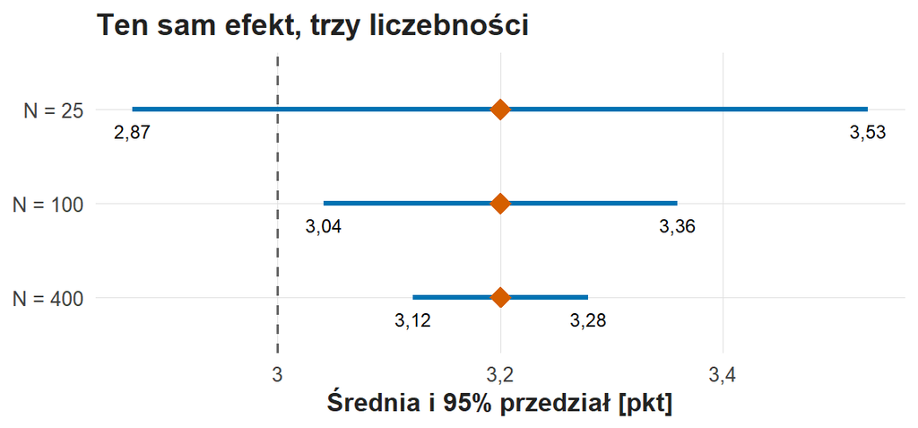

Ten sam efekt, trzy liczebności: 95% przedziały średniej 3,2 przy SD 0,8. N = 25: od 2,87 do 3,53; N = 100: od 3,04 do 3,36; N = 400: od 3,12 do 3,28. Szerokość maleje z 0,66 do 0,16 punktu; przedział przy N = 25 obejmuje odniesienie 3 (linia przerywana), a dwa pozostałe leżą powyżej niego.

```r
trzy_badania <- pokaz_wykres(wykres_n)
print(trzy_badania)
```

SE maleje, t rośnie, a p maleje wraz z N. Efekt pozostaje równy 0,2 punktu (d = 0,25); rośnie precyzja.

Przy małej próbie duży efekt ma szeroki przedział i duże p. Porównanie dwóch badań wymaga porównania ich efektów i przedziałów; dwie wartości p przy różnych N opisują głównie różną precyzję.

Osoba prowadząca bibliotekę otrzymuje najpierw efekt w punktach lub minutach oraz zakres wartości zgodnych z danymi, a potem wynik testu. Kolejność opisu oddziela liczbę obserwacji od wielkości korzyści.

## Punkt odniesienia ustalony przed analizą

Ten sam zbiór można porównać z różnymi wartościami; każda wartość odniesienia wyraża inne pytanie. Punkt 3 to środek skali, 3,5 — umowny cel instytucji, a średnia z innego badania ma własną niepewność.

Tabele „Ten sam 95% CI średniej [pkt]” i „Trzy pytania zerowe” podają dla S02: przedział średniej od 3,174 do 3,411 przy każdym odniesieniu; przy 3 t = 4,88 i p < 0,0001, przy 3,2 t = 1,54 i p = 0,126, przy 3,5 t = −3,46 i p = 0,0007.

```r
odniesienia <- zmiana_odniesienia()
print(odniesienia)
```

**Ten sam 95% CI średniej [pkt]**

| Dolna granica | Górna granica |
| --- | --- |
| 3,174 | 3,411 |

**Trzy pytania zerowe**

| Odniesienie [pkt] | Różnica [pkt] | t | p |
| --- | --- | --- | --- |
| 3,0 | 0,292 | 4,876 | < 0,0001 |
| 3,2 | 0,092 | 1,539 | 0,1259 |
| 3,5 | -0,208 | -3,465 | 0,0007 |

Zmiana odniesienia zmienia pytanie, a przedział średniej pozostaje ten sam. Zadanie Z05 stosuje odniesienie 3 z opisem jego umowności; inne odniesienie wymaga uzasadnienia przed analizą.

Odniesienie oszacowane w innej próbie ma własny błąd, więc problem staje się porównaniem dwóch oszacowań. Ćwiczenie C06 (Dwie grupy) wprowadza niepewność po obu stronach różnicy.

## Proporcja jako inna estymanda

W osobnym przykładzie 26 z 40 osób znajduje dokument. Estymata proporcji wynosi 0,65, czyli 65%. Porównanie z 50% dotyczy parametru $\pi$ — prawdopodobieństwa powodzenia w zdefiniowanym modelu. Zadanie Z05 dotyczy średniej; przykład proporcji ćwiczy rozpoznanie innej estymandy.

Próba Bernoulliego to pojedyncza próba z wynikiem 0/1 i stałym prawdopodobieństwem sukcesu $\pi$. Liczba sukcesów $K$ w 40 niezależnych próbach ma przy $H_0:\pi=0{,}5$ rozkład dwumianowy, a dwustronne p sumuje prawdopodobieństwa wyników nie bardziej prawdopodobnych niż obserwowany:

$$P(K=k)=\binom{40}{k}0{,}5^{40},\qquad
p=\sum_{k:\,P(K=k)\le P(K=26)}P(K=k)=P(K\ge26)+P(K\le14)=0{,}081 .$$

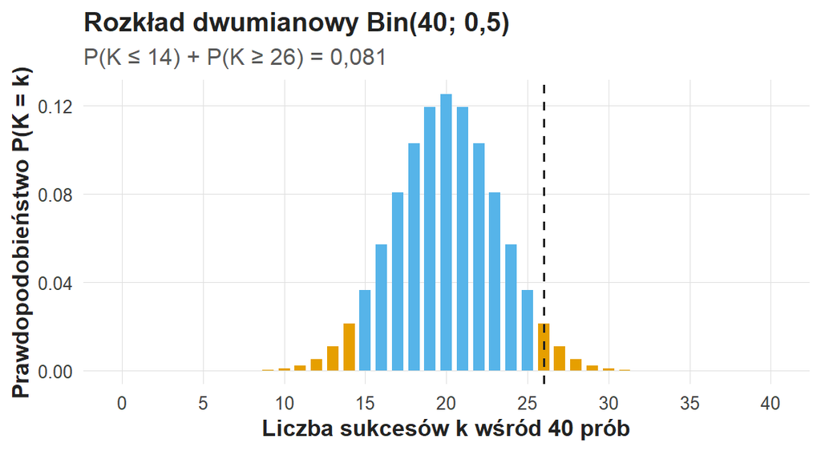

Rozkład dwumianowy Bin(40; 0,5). Oś pozioma: liczba sukcesów k wśród 40 prób; oś pionowa: prawdopodobieństwo. Słupki są symetryczne wokół 20; wyróżnione słupki k od 0 do 14 i od 26 do 40 mają łączne prawdopodobieństwo 0,081, a linia przerywana oznacza obserwowane 26 sukcesów.

```r
dwumianowy <- pokaz_wykres(wykres_dwumianowy)
print(dwumianowy)
```

Tabela „Pytanie o proporcję: dokładny test dwumianowy” podaje proporcję 0,650, przedział Cloppera–Pearsona od 0,483 do 0,794 i p = 0,0807.

```r
proporcja <- przyklad_proporcji_do_raportu()
print(proporcja)
```

**Pytanie o proporcję: dokładny test dwumianowy**

| Miara | Wartość |
| --- | --- |
| Sukcesy | 26 |
| N | 40 |
| Proporcja | 0,650 |
| Odniesienie (proporcja) | 0,500 |
| Dolna granica 95% CI | 0,483 |
| Górna granica 95% CI | 0,794 |
| p (test dwumianowy) | 0,0807 |

Liczba 65% opisuje próbę, a przedział — niepewność proporcji populacyjnej w modelu niezależnych prób Bernoulliego. Wynik osoby ma wartości 0 i 1, więc przedział dotyczy proporcji. Przedział [0,483; 0,794] obejmuje 0,5 i wartości do 0,79: dane są zgodne z szerokim zakresem skuteczności.

Symulacja modelu dwumianowego losuje liczbę sukcesów przy $\pi_0=0{,}5$; przetasowanie listy zer i jedynek zachowuje proporcję. Nazwa „Monte Carlo” wymaga dopowiedzenia, co jest losowane.

## Warsztat redakcyjny: pięć zdań do poprawy

### „Z prawdopodobieństwem 95% osoby mają średnią w tym zakresie”

Zdanie łączy osoby, średnią i poziom ufności. Poprawny opis brzmi: „95% przedział dla średniej wynosi …; poziom odnosi się do procedury konstrukcji przedziału przy jej założeniach”.

Opis osób korzysta z SD, kwantyli i histogramu, a przewidywanie wyniku nowej osoby — z przedziału predykcji. Trzy pytania wymagają trzech par granic.

### „P < 0,001 dowodzi wysokich kompetencji”

Test dotyczył średniej indeksu względem 3. Poprawiona wersja mówi o średniej deklarowanej użyteczności według zastosowanego pomiaru i o różnicy od umownego odniesienia.

Wniosek o kompetencjach wymaga adekwatnego pomiaru, a wniosek o skutku poprawy katalogu — projektu porównawczego.

### „Bootstrap potwierdził hipotezę, bo większość średnich jest powyżej trzech”

Zwykły bootstrap opisuje zmienność estymatora wokół średniej próby. Opis podaje bootstrapowy przedział i jego położenie względem odniesienia, z nazwą procedury, parametru i ograniczeń.

Poprawa przestawia argument: estymata, niepewność według metody, zakres pytania.

### „Permutacja nie ma założeń, więc zawsze jest ważniejsza”

Test zmian znaków zakłada symetrię i niezależność odchyleń. Przy skośnym czasie równość średniej i odniesienia pozostawia symetrię jako osobny warunek.

Poprawiony opis podaje, co zmieniano i dlaczego zmiany znaków są dopuszczalne przy $H_0$. Przy wątpliwym warunku wynik przedstawia się jako analizę pod dodatkowym modelem.

### „Dwa p są małe, więc ograniczenia próby nie mają znaczenia”

Obie procedury korzystają z tych samych danych i dzielą ich ograniczenia doboru i pomiaru, w tym nieodpowiedzi osób z największą trudnością.

Lepsze zdanie oddziela dwa poziomy: „Wyniki obu procedur przy ich założeniach wskazują na odchylenie od odniesienia; zakres uogólnienia ogranicza projekt i jakość pomiaru”.

## Średnia i symetria: dwa warunki

Osobna demonstracja czasu: dziewięć osób kończy po 9 minutach, jedna po 19. Suma wynosi 100, a średnia 10 minut. Względem odniesienia 10 powstaje dziewięć odchyleń −1 i jedno +9: średnia 0, rozkład asymetryczny.

Przykład wyjaśnia logikę warunku: „średnia równa 10” i „symetryczne odchylenia” to dwa warunki. Gdy populację tworzą wyłącznie czasy 9 i 19 minut, zmiany znaków tworzą odchylenie −9, czyli czas 1 minuty spoza populacji.

Czas 19 minut jest prawidłową obserwacją ujawniającą trudność usługi. Zmiana parametru na medianę wymaga zmiany pytania.

Przy czasie w miejsce indeksu tor zmian znaków wymaga szczególnej ostrożności: algorytm działa pod dodatkowym założeniem symetrii. Metodę dobiera się do celu i rozkładu.

## Niezależność jest własnością projektu

Inny zespół bada 15 osób, z których każda wykonuje dziesięć zapytań, i liczy SE ze 150 wierszy. Dokładność odpowiada bliżej 15 osobom niż 150: czasy jednej osoby są podobne z powodu jej umiejętności, sprzętu i sposobu pracy (efektywna liczebność, wykład W03).

Zależność ujawnia identyfikator osoby i informacja o zadaniach. Wynikiem osoby może być średni czas ustalonego zestawu zadań; alternatywą jest model uwzględniający powtórzenia. Wybór zależy od celu.

W S02 jednostkę określa scenariusz, a identyczne duplikaty usuwa jawna reguła. N wynika z jednostki analizy ustalonej przed losowaniem; bootstrap osób i zmiany znaków działają na osobach.

## Notatka przed uruchomieniem testu

Krótka notatka analityczna zawiera nazwę zmiennej, estymandę, odniesienie, kierunek odejmowania, regułę braków, powód wyboru procedury, poziom ufności i porównanie główne. Notatka jest krótka i ogranicza zmianę pytania po wyniku.

Po obliczeniu notatka podaje odstępstwa i dodatkowe analizy; plan pozostaje w notatce obok opisu odstępstw. Wzorzec z eksploracji nosi nazwę eksploracyjnego i otrzymuje propozycję nowego badania.

Ćwiczenie C06 (Dwie grupy) porównuje dwie grupy użytkowników. W miejscu znanej stałej pojawi się druga oszacowana średnia. Zasada pozostaje: najpierw kierunek i jednostka efektu, potem niepewność, statystyka i warunki testu.